# Google Data Analytics Certification — R Practice Notebook

### 8.3 Trend Lines (Per Group vs. Overall)

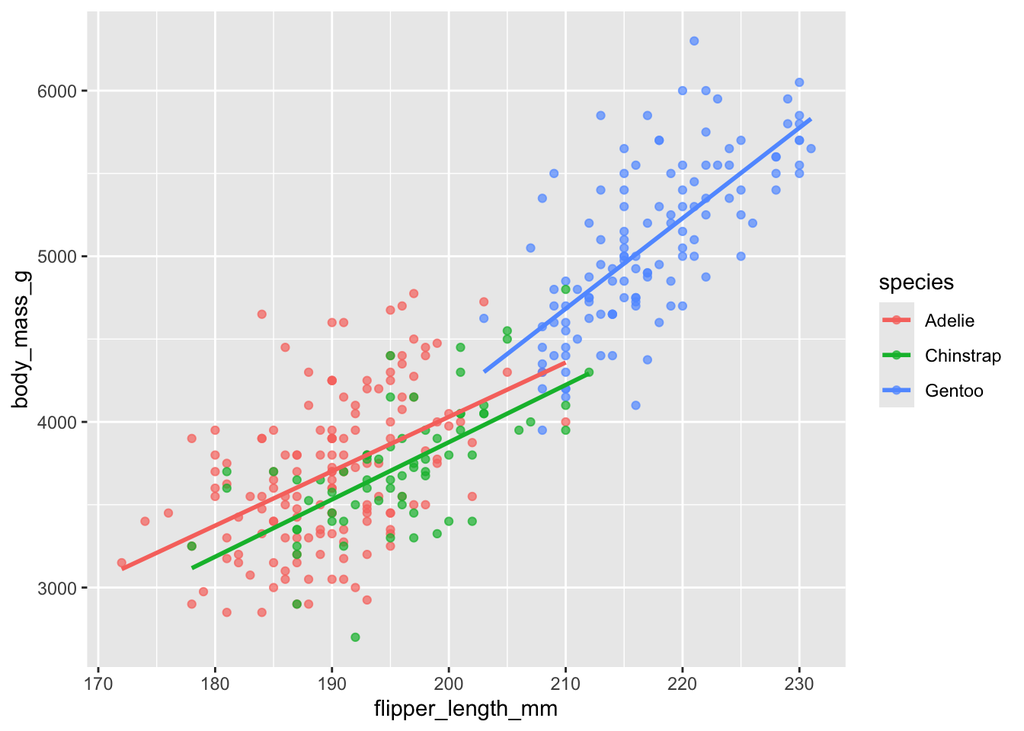

```r
# One trend line per species (color mapped globally)
ggplot(penguins, aes(x = flipper_length_mm, y = body_mass_g, color = species)) +
  geom_point(alpha = 0.7) +
  geom_smooth(method = "lm", se = FALSE)
```

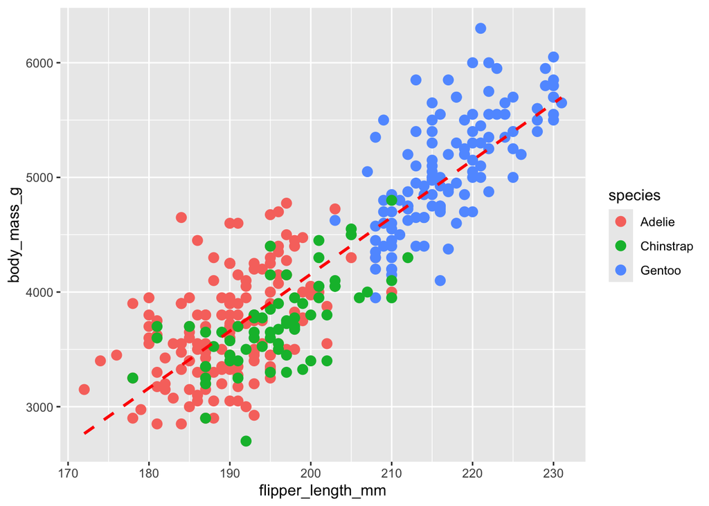

```r
# Single overall trend line (color mapped only inside geom_point)
ggplot(penguins, aes(x = flipper_length_mm, y = body_mass_g)) +
  geom_point(aes(color = species), size = 3) +
  geom_smooth(method = "lm", se = FALSE, color = "red", linetype = "dashed")
```

### 8.4 Faceting (Small Multiples)

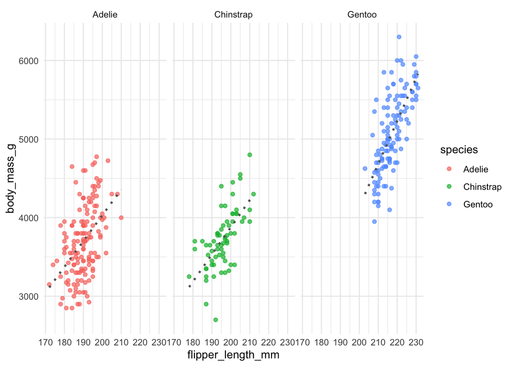

```r
ggplot(penguins, aes(x = flipper_length_mm, y = body_mass_g)) +
  geom_point(aes(color = species), alpha = 0.7) +
  geom_smooth(method = "lm", se = FALSE, color = "gray40", linetype = "dotted") +
  facet_wrap(~species) +
  theme_minimal()
```

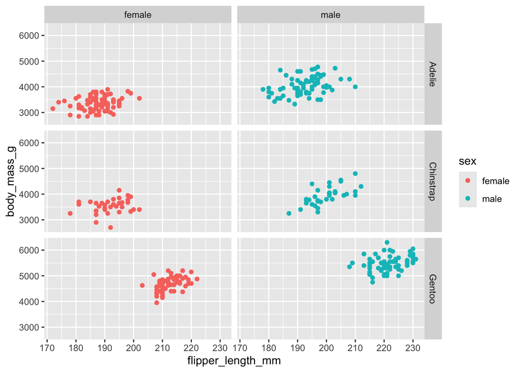

```r
# Two-way faceting with facet_grid (NA rows removed first — ggplot can't drop them itself)
ggplot(data = na.omit(penguins)) +
  geom_point(aes(x = flipper_length_mm, y = body_mass_g, color = sex)) +
  facet_grid(species ~ sex)
```

### 8.5 Polished, Presentation-Ready Plot

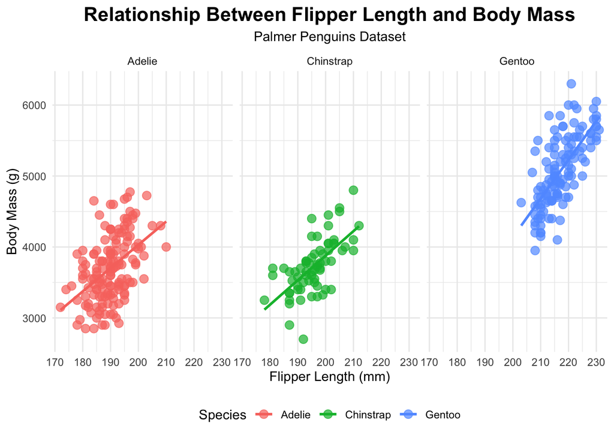

```r
ggplot(data = penguins,
       aes(x = flipper_length_mm, y = body_mass_g, color = species)) +
  geom_point(size = 3, alpha = 0.7) +
  geom_smooth(method = "lm", se = FALSE) +
  facet_wrap(~species) +
  labs(
    title = "Relationship Between Flipper Length and Body Mass",
    subtitle = "Palmer Penguins Dataset",
    x = "Flipper Length (mm)",
    y = "Body Mass (g)",
    color = "Species"
  ) +
  theme_minimal() +
  theme(
    plot.title = element_text(face = "bold", size = 16, hjust = 0.5),
    plot.subtitle = element_text(hjust = 0.5),
    legend.position = "bottom"
  )
```

### 8.6 Comparing Distributions (Boxplot, Violin, Density)

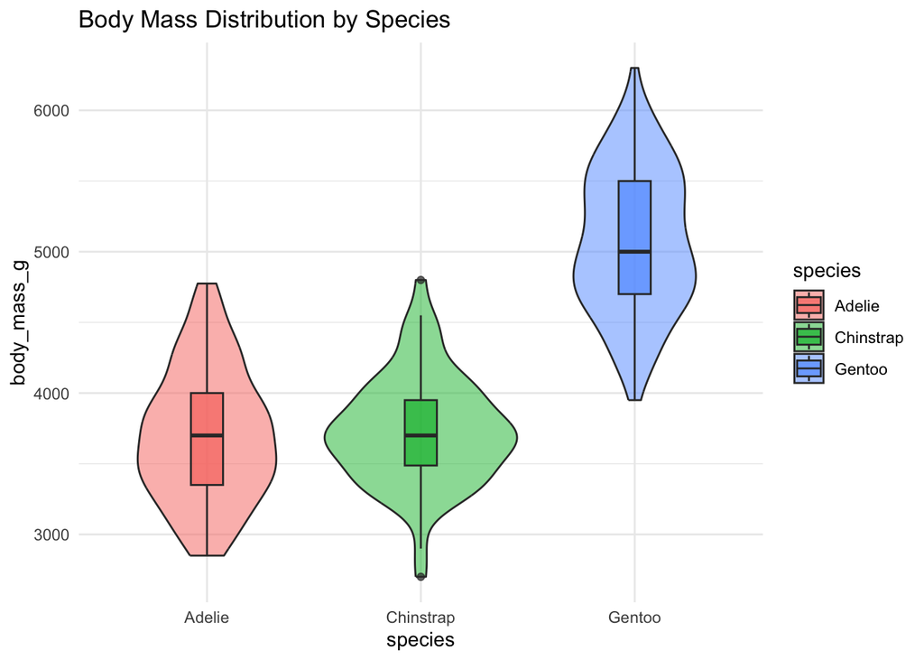

```r
ggplot(penguins, aes(x = species, y = body_mass_g, fill = species)) +
  geom_violin(alpha = 0.5) +
  geom_boxplot(width = 0.15, alpha = 0.7) +
  theme_minimal() +
  labs(title = "Body Mass Distribution by Species")
```

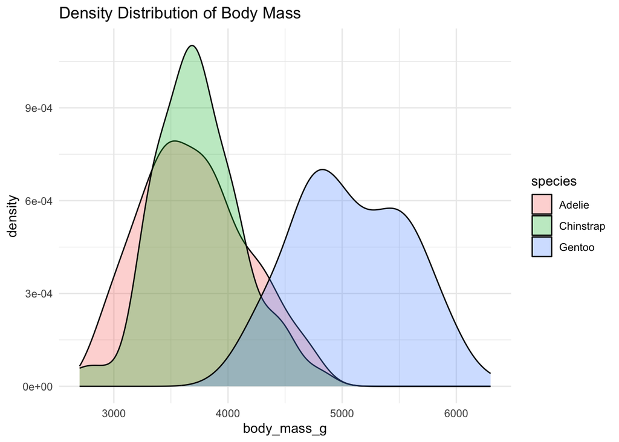

```r
ggplot(penguins, aes(x = body_mass_g, fill = species)) +
  geom_density(alpha = 0.3) +
  theme_minimal() +
  labs(title = "Density Distribution of Body Mass")
```

### 8.7 Bar Charts

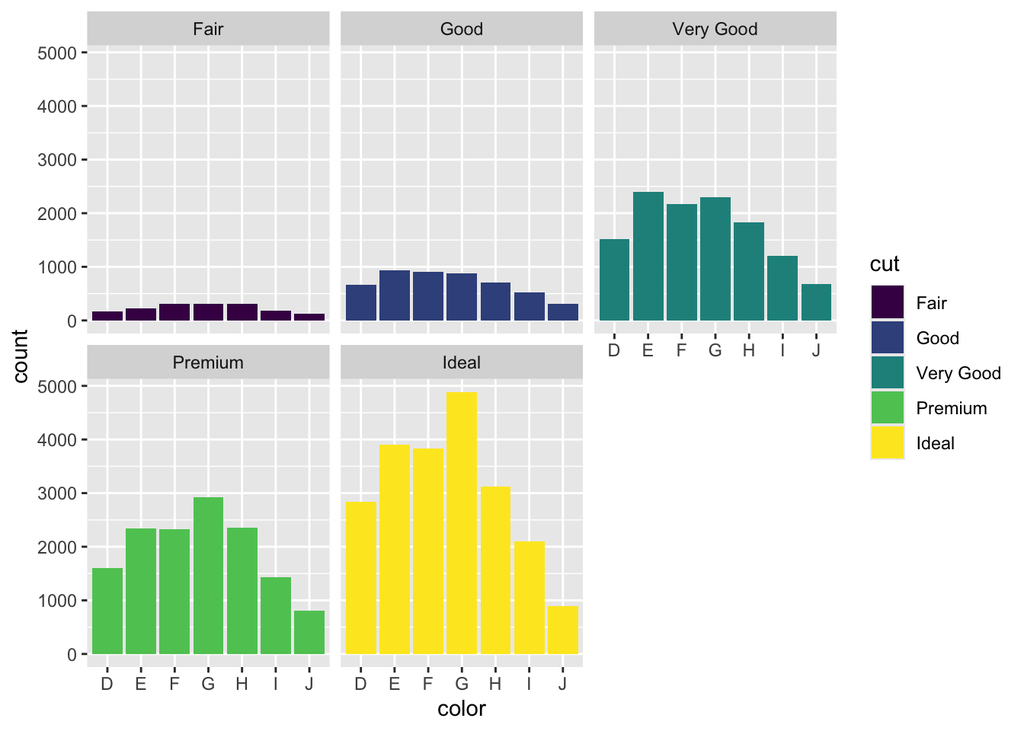

```r
ggplot(data = diamonds) +
  geom_bar(mapping = aes(x = color, fill = cut)) +
  facet_wrap(~cut)
```

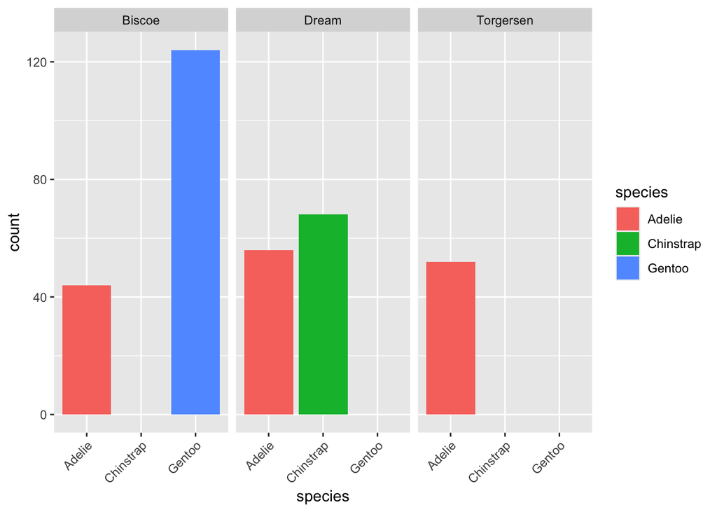

```r
# Rotated axis labels for long category names
ggplot(data = penguins) +
  geom_bar(mapping = aes(x = species, fill = species)) +
  facet_wrap(~island) +
  theme(axis.text.x = element_text(angle = 45, hjust = 1))
```

### 8.8 Annotations

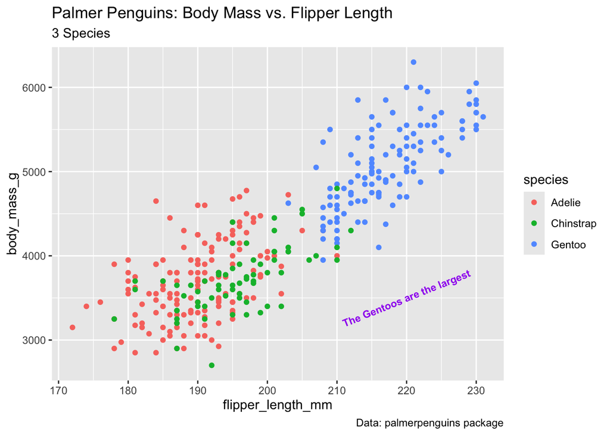

```r
ggplot(data = penguins) +
  geom_point(mapping = aes(x = flipper_length_mm, y = body_mass_g, color = species)) +
  labs(
    title = "Palmer Penguins: Body Mass vs. Flipper Length",
    subtitle = "3 Species",
    caption = "Data: palmerpenguins package"
  ) +
  annotate("text", x = 220, y = 3500, label = "The Gentoos are the largest",
           color = "purple", fontface = "bold", size = 3, angle = 22)
```

### 8.9 Why Visualize? Anscombe’s Quartet & the Datasaurus Dozen

These two datasets are the classic teaching example for *why summary statistics alone are not enough* — very different-looking data can share nearly identical means, standard deviations, and correlations.

```r
library(Tmisc)
data("quartet")

quartet %>%
  group_by(set) %>%
  summarise(mean_x = mean(x), sd_x = sd(x), mean_y = mean(y), sd_y = sd(y), cor_xy = cor(x, y))
```

| set | mean_x | sd_x | mean_y | sd_y | cor_xy |
| --- | --- | --- | --- | --- | --- |
| I | 9 | 3.316625 | 7.500909 | 2.031568 | 0.8164205 |
| II | 9 | 3.316625 | 7.500909 | 2.031657 | 0.8162365 |
| III | 9 | 3.316625 | 7.500000 | 2.030424 | 0.8162867 |
| IV | 9 | 3.316625 | 7.500909 | 2.030579 | 0.8165214 |

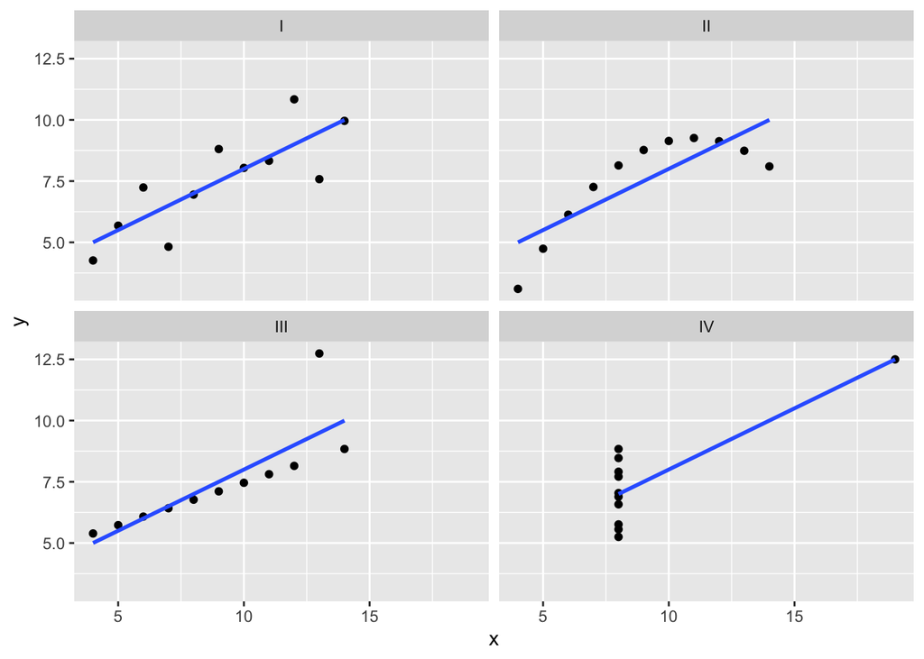

```r
ggplot(quartet, aes(x, y)) +
  geom_point() +
  geom_smooth(method = "lm", se = FALSE) +
  facet_wrap(~set)
```

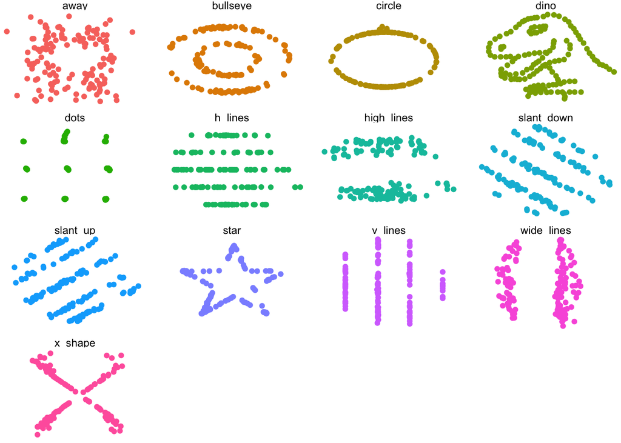

```r
library(datasauRus)
data(datasaurus_dozen)

ggplot(datasaurus_dozen, aes(x = x, y = y, colour = dataset)) +
  geom_point() +
  theme_void() +
  theme(legend.position = "none") +
  facet_wrap(~dataset, ncol = 4)
```

### 8.10 Saving a Plot

```r
ggsave("penguin_species_plot.png")
```

## Summary

This notebook covers, in order: dates/times, base R conditionals and subsetting, importing and inspecting data, `dplyr` cleaning verbs, grouping/summarizing, bias checking, and a full `ggplot2` visualization progression from a bare scatter plot to faceted, annotated, presentation-ready charts.